# White Wine Exploration by Divya Ramanujachari

### Plot Two

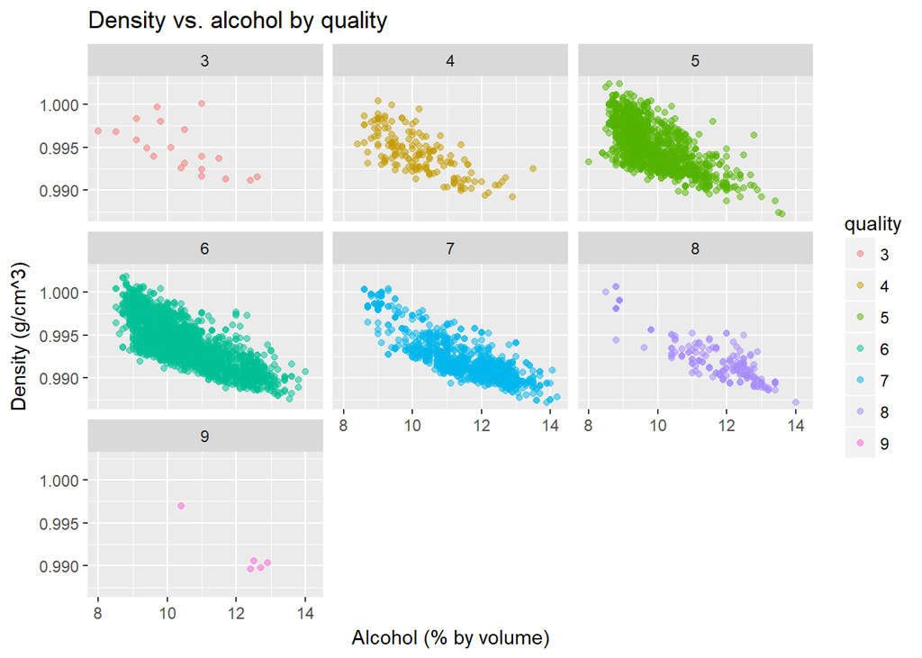

### Description Two

I chose this plot as it clearly demonstrates one of the key findings of this study. Specifically, there is a negative correlation between the density and alcohol levels. Also, it is observed that, high quality wines typically have high alcohol content and minimum values of density.

### Plot Three

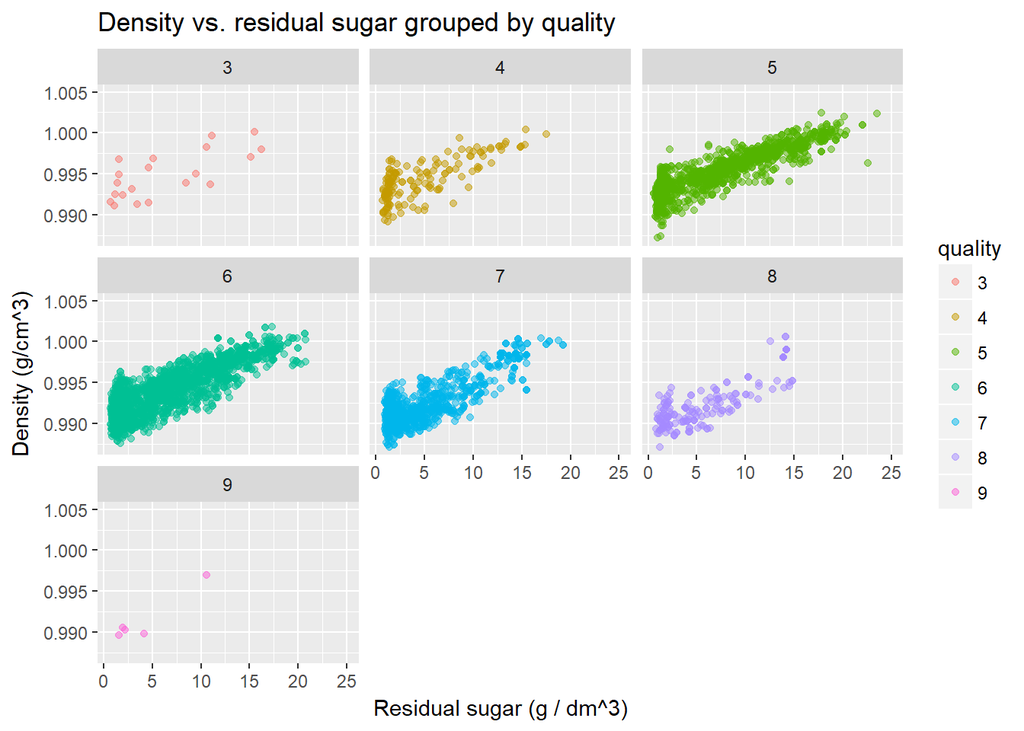

### Description Three

This plot shows that a positive correlation exists between the density and residual sugar across wines of all qualities. Furthermore, it is observed that high quality wines tend to have low values of density as well as residual sugar.

# Reflection

In this project, I performed an exploration of physicochemical parameters of 4898 samples of white wine to analyze whether any of the parameters have a direct effect of the quality. It was found that higher quality wines did exhibit some characteristic features of low density, low residual sugar, and high alcohol content. However, some lower quality wines too possess the same characteristics. Further analysis is needed to establish a more comprehensive model. This could be achieved by adding more data points and taking into consideration other features as well.